# R Open Labs

## Reproducible Report with RMarkdown

#### University of North Carolina at Chapel Hill

#### Nov 1, 2018

## Data and other downloads

[Download Brazil e-commerce RStudio Project](https://github.com/UNC-Libraries-data/R-Open-Labs/raw/master/week7_RMarkdown/download/brazil_ecommerce_project.zip)

Also, make sure you have installed the GGally R library. If you haven’t, you can do so using the code `install.packages("GGally")`

Data derived from [Brazilian E-Commerce Public Dataset by Olist](https://www.kaggle.com/olistbr/brazilian-ecommerce) provided on Kaggle.com under a [CC BY-NC-SA 4.0](https://creativecommons.org/licenses/by-nc-sa/4.0/) license.

## Today

This workshop covers topics from:

[Chapter 27](https://r4ds.had.co.nz/r-markdown.html)

## Motivation

R Markdown provides a straightforward way to create reports that combine code and the output from that code with text commentary. This allows for the creation of automated, reproducible reports. R Markdown can knit together your analysis results with text and output it directly into HTML, PDF, or Word documents. In fact, we have been using R Markdown to generate the webpage for all of our R Open Labs workshops!

Last week, Matt provided [a great set of exercises exploring some Brazilian e-commerce data](https://unc-libraries-data.github.io/R-Open-Labs/week6_MergeReshape/R_OpenLabs_6_MergeReshape.html#Exercises). Suppose you created an R Studio project and completed those exercises in an R script (available as zip file in the Download link at the top of this page). For this workshop, let’s turn that R script into an HTML report using R Markdown.

Before we continue, unzip the brazil_ecommerce_project.zip file, and open the project in RStudio.

## R Markdown

R Markdown has three components.

1. An (optional) header in a language called YAML. This allows you to specify the type of output file and configure other options.
2. R code chunks wrapped by `` ``` ``
3. Text mixed with simple formatting markup.

To create a new R Markdown document (.Rmd), select File -> New File -> R Markdown.

You will have the option to select the output: we’ll use the default HTML for this workshop.

Give the document a title and enter your name as author: this will create the header for you at the top of your new .html page!

RStudio will create a new R Markdown document filled with examples of code chunks and text.

## Header

At the top of the page is the optional Yet Another Markup Language (YAML) header. This header is a powerful way to edit the formatting of your report (e.g. figure dimensions, presence of a table of contents, identifying the location of a bibliography file).

## Code Chunks

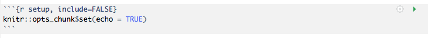

R code chunks are surrounded by `` ``` ``. Inside the curly braces, it specifies that this code chunk will use R code (other programming languages are supported), then it names this chunk “setup”. Each code chunk in your document has to have a unique name. After the name, you specify options on whether you want the code or its results to be displayed in the final document. For this chunk, the `include=FALSE` options tells R Markdown that we want this code to run, but we do not want it to be displayed in the final HTML document. The R code inside the chunk `knitr::opts_chunk$set(echo = TRUE)` tells R Markdown to display the R code along with the results of the code in the HTML output for all code chunks below.

## Formatted Text

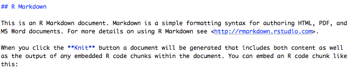

This is plain text with simple formatting added. The `##` tells R Markdown that “R Markdown” is a section header. The `**` around “Knit” tells R Markdown to make that word **bold**.

The RStudio team has helpfully condensed these code chunk and text formatting options into a [cheatsheet](https://www.rstudio.com/wp-content/uploads/2015/02/rmarkdown-cheatsheet.pdf).

You can get pretty far with options in the R Markdown cheatsheet, but R Markdown is very powerful, flexible language that we do not have time to fully cover. More detailed references are:

https://www.rstudio.com/wp-content/uploads/2015/03/rmarkdown-reference.pdf

https://bookdown.org/yihui/rmarkdown

## Tables

By default, R Markdown will display tables the way they appear in the R console. We can use `knitr::kable` function to get cleaner tables.

```r
knitr::kable(
  mtcars[1:5, ],
  caption = "A knitr kable."
)
```

A knitr kable.

|  | mpg | cyl | disp | hp | drat | wt | qsec | vs | am | gear | carb |
| --- | --- | --- | --- | --- | --- | --- | --- | --- | --- | --- | --- |
| Mazda RX4 | 21.0 | 6 | 160 | 110 | 3.90 | 2.620 | 16.46 | 0 | 1 | 4 | 4 |
| Mazda RX4 Wag | 21.0 | 6 | 160 | 110 | 3.90 | 2.875 | 17.02 | 0 | 1 | 4 | 4 |
| Datsun 710 | 22.8 | 4 | 108 | 93 | 3.85 | 2.320 | 18.61 | 1 | 1 | 4 | 1 |
| Hornet 4 Drive | 21.4 | 6 | 258 | 110 | 3.08 | 3.215 | 19.44 | 1 | 0 | 3 | 1 |
| Hornet Sportabout | 18.7 | 8 | 360 | 175 | 3.15 | 3.440 | 17.02 | 0 | 0 | 3 | 2 |

## Generating the HTML document

This is quite straightforward. Click the **Knit** button, and R Studio will generate an HTML report based on your R Markdown document.

## Exercises:

1. Convert the `analysis.R` script into an R Markdown document that creates an HTML report.
2. Find another project you have been working on using R. Tidy everything up into an RStudio project and generate an HTML report using R Markdown. Now, send the RStudio project to a friend (or us!), and ask them to knit that R Markdown document. The goal is to have packaged everything up neatly so that your friend can easily run your code and create exactly the same HTML document that you did.

## Feedback

[Let us know what you think of this lesson!](https://unc.az1.qualtrics.com/jfe/form/SV_8e1zRY2rlFUYBMx)